# Coursera Data Science - Practical Machine Learning Assignment

Alexander van der Kuijl

September 9, 2018

## Introduction

In this article we are going to explore the following question: can we predict how well a barbell lift is executed based on accelerometer data. The data is provided in the Weight Lifting Exercise Dataset, provided by Groupware@LES. It contains 160 variables, one of them being a Classe variable indicating whether the exercise was performed correctly (Classe A), or incorrectly (Classe B-E). We are going to investigate whether the other variables (device measurements during the exercise) can be used together to create a prediction model to predict whether the weight lifting exercise was performed correctly (i.e. the Classe variable).

## Data reading and preparation

We read the provided data set (csv-file) in and create testing and training set.

```r
suppressPackageStartupMessages(library(caret))
suppressPackageStartupMessages(library(e1071))
pmlTrain <- read.csv("pml-training.csv", na.strings=c("NA","#DIV/0!",""))
set.seed(3456)
inTrain <- createDataPartition(pmlTrain$classe, p=0.6, list=FALSE)
myTraining <- pmlTrain[inTrain, ]
myTesting <- pmlTrain[-inTrain, ]
dim(myTraining); dim(myTesting)
```

```
## [1] 11776   160
```

```
## [1] 7846  160
```

```r
nzv <- nearZeroVar(myTraining, saveMetrics=TRUE)
myTraining <- myTraining[,nzv$nzv==FALSE]

# nzv2<- nearZeroVar(myTesting,saveMetrics=TRUE)
myTesting <- myTesting[,nzv$nzv==FALSE]

myTraining <- myTraining[-c(1, 3, 4, 5)]
myTesting <- myTesting[-c(1, 3, 4, 5)]

# Remove columns with too many NAs
okColumns <- colMeans(is.na(myTraining)) < .75

finalMyTraining <- myTraining[, okColumns]
finalMyTesting <- myTesting[, okColumns]

dim(finalMyTraining)
```

```
## [1] 11776    55
```

```r
dim(finalMyTesting)
```

```
## [1] 7846   55
```

The resulting dataset has 55 columns, already quite less than the initial 160.

## Exploratory Data Analysis

In the Exploratory Data Analysis we are plotting each variable against the Classe variable to determine whether we can visually determine correlations, patterns, etc. between the predictors and the outcome. This can also be used to further reduce the variables we are going to include in our prediction model. We have created a script that generates a boxplot and a violin plot for each variable. The plots for one of the variables can be found in the Appendix.

## Model Creation

We will look at various models to build a prediction model, and use our own created test data set to assess the performance.

- Decision Tree

```r
suppressPackageStartupMessages(library(rpart))
fitRPart <- rpart(classe ~ ., data=finalMyTraining, method="class")
predictionsRPart <- predict(fitRPart, finalMyTesting, type = "class")
```

- Random Forest

```r
suppressPackageStartupMessages(library(randomForest))
set.seed(3456)
fitRF <- randomForest(classe ~ ., data=finalMyTraining)
predictionRF <- predict(fitRF, finalMyTesting, type = "class")
```

- Neural Network

```r
fitNN <- train(classe ~ ., data=finalMyTraining, method="nnet")
predictionNN <- predict(fitNN, finalMyTesting)
```

- Support Vector Machine

```r
fitSVM <- train(classe ~ ., data=finalMyTraining, method="svmLinear")
predictionSVM <- predict(fitSVM, finalMyTesting)
```

- k-Nearest Neighbors

```r
fitKNN <- train(classe ~ ., data=finalMyTraining, method="knn")
predictionKNN <- predict(fitKNN, finalMyTesting)
```

- Gradient Boosted Machine

```r
fitControl <- trainControl(method = "repeatedcv",
                           number = 5,
                           repeats = 1)
fitGBM <- train(classe ~ ., data=finalMyTraining, method="gbm", trControl = fitControl)
predictionGBM <- predict(fitGBM, finalMyTesting)
```

## Model Evaluation

As a next step we are going to evaluate the generated models. We are going to look at the Confusion Matrix of the results based on the predictions on the test data set.

```r
ConfMatrixRPart <- confusionMatrix(predictionsRPart, finalMyTesting$classe)
ConfMatrixRF <- confusionMatrix(predictionRF, finalMyTesting$classe)
ConfMatrixNN <- confusionMatrix(predictionNN, finalMyTesting$classe)
ConfMatrixSVM <- confusionMatrix(predictionSVM, finalMyTesting$classe)
ConfMatrixKNN <- confusionMatrix(predictionKNN, finalMyTesting$classe)
ConfMatrixGBM <- confusionMatrix(predictionGBM, finalMyTesting$classe)
```

## Conclustion

Based on the information provided in the Confusion Matrices (see Appendix) both the Random Forest and the Generalized Boosted Regression models are the best performing ones. The Random Forest one is even better, with a very high Accuracy. For prediction purposes we will therefore be using the Random Forest Model.

## Appendix

### Exploratory Data Analysis plots:

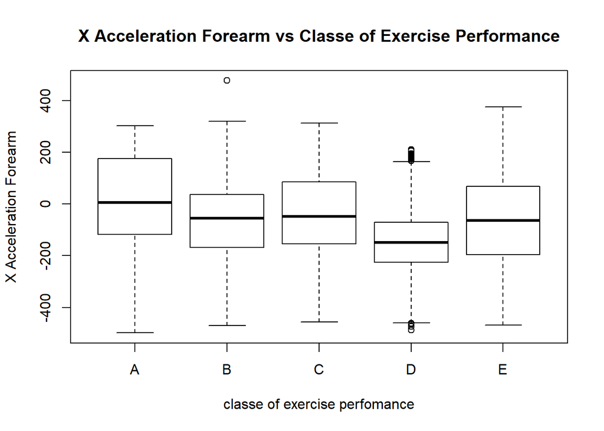

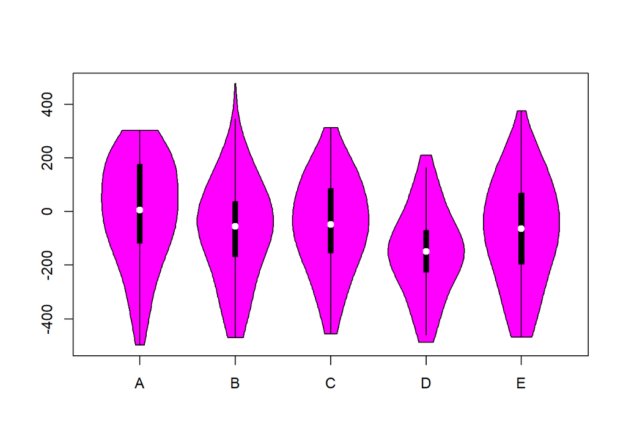

### Confusion Matrices

```r
ConfMatrixRPart
```

```
## Confusion Matrix and Statistics
##
##           Reference
## Prediction    A    B    C    D    E
##          A 2095  190   57   64   14
##          B   54 1116   81   51   68
##          C   32  108 1149   42    7
##          D   44   60   63 1035  131
##          E    7   44   18   94 1222
##
## Overall Statistics
##
##                Accuracy : 0.8434
##                  95% CI : (0.8351, 0.8513)
##     No Information Rate : 0.2845
##     P-Value [Acc > NIR] : < 2.2e-16
##
##                   Kappa : 0.8013
##  Mcnemar's Test P-Value : < 2.2e-16
##
## Statistics by Class:
##
##                      Class: A Class: B Class: C Class: D Class: E
## Sensitivity            0.9386   0.7352   0.8399   0.8048   0.8474
## Specificity            0.9421   0.9599   0.9708   0.9546   0.9745
## Pos Pred Value         0.8657   0.8146   0.8587   0.7764   0.8823
## Neg Pred Value         0.9748   0.9379   0.9663   0.9615   0.9659
## Prevalence             0.2845   0.1935   0.1744   0.1639   0.1838
## Detection Rate         0.2670   0.1422   0.1464   0.1319   0.1557
## Detection Prevalence   0.3084   0.1746   0.1705   0.1699   0.1765
## Balanced Accuracy      0.9404   0.8475   0.9054   0.8797   0.9110
```

```r
ConfMatrixRF
```

```
## Confusion Matrix and Statistics
##
##           Reference
## Prediction    A    B    C    D    E
##          A 2232    2    0    0    0
##          B    0 1516    6    0    0
##          C    0    0 1362    9    0
##          D    0    0    0 1277    2
##          E    0    0    0    0 1440
##
## Overall Statistics
##
##                Accuracy : 0.9976
##                  95% CI : (0.9962, 0.9985)
##     No Information Rate : 0.2845
##     P-Value [Acc > NIR] : < 2.2e-16
##
##                   Kappa : 0.9969
##  Mcnemar's Test P-Value : NA
##
## Statistics by Class:
##
##                      Class: A Class: B Class: C Class: D Class: E
## Sensitivity            1.0000   0.9987   0.9956   0.9930   0.9986
## Specificity            0.9996   0.9991   0.9986   0.9997   1.0000
## Pos Pred Value         0.9991   0.9961   0.9934   0.9984   1.0000
## Neg Pred Value         1.0000   0.9997   0.9991   0.9986   0.9997
## Prevalence             0.2845   0.1935   0.1744   0.1639   0.1838
## Detection Rate         0.2845   0.1932   0.1736   0.1628   0.1835
## Detection Prevalence   0.2847   0.1940   0.1747   0.1630   0.1835
## Balanced Accuracy      0.9998   0.9989   0.9971   0.9963   0.9993
```

```r
ConfMatrixNN
```

```
## Confusion Matrix and Statistics
##
##           Reference
## Prediction    A    B    C    D    E
##          A 1297  165  157   34  137
##          B  361  905  330  419  812
##          C  549  333  812  725  419
##          D   21   84   41  108   38
##          E    4   31   28    0   36
##
## Overall Statistics
##
##                Accuracy : 0.4025
##                  95% CI : (0.3916, 0.4134)
##     No Information Rate : 0.2845
##     P-Value [Acc > NIR] : < 2.2e-16
##
##                   Kappa : 0.2474
##  Mcnemar's Test P-Value : < 2.2e-16
##
## Statistics by Class:
##
##                      Class: A Class: B Class: C Class: D Class: E
## Sensitivity            0.5811   0.5962   0.5936  0.08398 0.024965
## Specificity            0.9122   0.6963   0.6872  0.97195 0.990162
## Pos Pred Value         0.7246   0.3201   0.2861  0.36986 0.363636
## Neg Pred Value         0.8456   0.8779   0.8890  0.84406 0.818510
## Prevalence             0.2845   0.1935   0.1744  0.16391 0.183788
## Detection Rate         0.1653   0.1153   0.1035  0.01376 0.004588
## Detection Prevalence   0.2281   0.3603   0.3617  0.03722 0.012618
## Balanced Accuracy      0.7466   0.6462   0.6404  0.52797 0.507564
```

```r
ConfMatrixSVM
```

```
## Confusion Matrix and Statistics
##
##           Reference
## Prediction    A    B    C    D    E
##          A 2048  189  109   78   43
##          B   67 1130  118   41  150
##          C   57   77 1089  129  100
##          D   59   26   33  990   73
##          E    1   96   19   48 1076
##
## Overall Statistics
##
##                Accuracy : 0.8072
##                  95% CI : (0.7983, 0.8158)
##     No Information Rate : 0.2845
##     P-Value [Acc > NIR] : < 2.2e-16
##
##                   Kappa : 0.7551
##  Mcnemar's Test P-Value : < 2.2e-16
##
## Statistics by Class:
##
##                      Class: A Class: B Class: C Class: D Class: E
## Sensitivity            0.9176   0.7444   0.7961   0.7698   0.7462
## Specificity            0.9254   0.9406   0.9440   0.9709   0.9744
## Pos Pred Value         0.8302   0.7503   0.7500   0.8383   0.8677
## Neg Pred Value         0.9658   0.9388   0.9564   0.9556   0.9446
## Prevalence             0.2845   0.1935   0.1744   0.1639   0.1838
## Detection Rate         0.2610   0.1440   0.1388   0.1262   0.1371
## Detection Prevalence   0.3144   0.1919   0.1851   0.1505   0.1580
## Balanced Accuracy      0.9215   0.8425   0.8700   0.8704   0.8603
```

```r
ConfMatrixKNN
```

```
## Confusion Matrix and Statistics
##
##           Reference
## Prediction    A    B    C    D    E
##          A 2118   64   18   34   13
##          B   23 1333   55   11   45
##          C   30   63 1233   98   26
##          D   49   42   51 1119   63
##          E   12   16   11   24 1295
##
## Overall Statistics
##
##                Accuracy : 0.9047
##                  95% CI : (0.898, 0.9111)
##     No Information Rate : 0.2845
##     P-Value [Acc > NIR] : < 2.2e-16
##
##                   Kappa : 0.8794
##  Mcnemar's Test P-Value : 3.555e-16
##
## Statistics by Class:
##
##                      Class: A Class: B Class: C Class: D Class: E
## Sensitivity            0.9489   0.8781   0.9013   0.8701   0.8981
## Specificity            0.9770   0.9788   0.9665   0.9688   0.9902
## Pos Pred Value         0.9426   0.9087   0.8503   0.8452   0.9536
## Neg Pred Value         0.9796   0.9710   0.9789   0.9744   0.9773
## Prevalence             0.2845   0.1935   0.1744   0.1639   0.1838
## Detection Rate         0.2699   0.1699   0.1572   0.1426   0.1651
## Detection Prevalence   0.2864   0.1870   0.1848   0.1687   0.1731
## Balanced Accuracy      0.9630   0.9285   0.9339   0.9194   0.9441
```

```r
ConfMatrixGBM
```

```
## Confusion Matrix and Statistics
##
##           Reference
## Prediction    A    B    C    D    E
##          A 2224    9    0    0    0
##          B    7 1486   13    5    7
##          C    0   18 1354   17    5
##          D    1    4    1 1261   18
##          E    0    1    0    3 1412
##
## Overall Statistics
##
##                Accuracy : 0.9861
##                  95% CI : (0.9833, 0.9886)
##     No Information Rate : 0.2845
##     P-Value [Acc > NIR] : < 2.2e-16
##
##                   Kappa : 0.9824
##  Mcnemar's Test P-Value : NA
##
## Statistics by Class:
##
##                      Class: A Class: B Class: C Class: D Class: E
## Sensitivity            0.9964   0.9789   0.9898   0.9806   0.9792
## Specificity            0.9984   0.9949   0.9938   0.9963   0.9994
## Pos Pred Value         0.9960   0.9789   0.9713   0.9813   0.9972
## Neg Pred Value         0.9986   0.9949   0.9978   0.9962   0.9953
## Prevalence             0.2845   0.1935   0.1744   0.1639   0.1838
## Detection Rate         0.2835   0.1894   0.1726   0.1607   0.1800
## Detection Prevalence   0.2846   0.1935   0.1777   0.1638   0.1805
## Balanced Accuracy      0.9974   0.9869   0.9918   0.9885   0.9893
```